# PS811: Introduction to Statistical Computing Final Project Portfolio

Juan Qian

### Personal Background

I am a doctoral student in the Political Science Department at the University of Wisconsin-Madison. My fields of interest are political methodology and comparative politics.

My hometown is Nanjing, a city in eastern China. I graduated from Macalester College (Minnesota) with a B.A. in political science and history in 2014 and obtained my Master’s degree in public policy and economic policy from Georgetown University in 2016.

### Research Interests

In general, I am interested in the formation, evolution and spread of identities and narratives within and between groups of people. Region-wise, I am interested in the ethnic identities, assimilation and resistence of minority groups in modern China.

### Motivation & Background

The core question is: does gender affect one’s perception of local government performance in different provinces?

#### Why does gender matters in political opinion research?

Many studies find that males and females have different views on certain political issues. Under authoritarian regimes specifically, some studies suggest that women show more apathy towards politics than men. The difference in attitudes towards politics are specifically salient in conservative, patriarchical societies where women are confined to their traditional gender roles. Whether gender affects poliitical views motivates me to perform this data visualization.

#### Why are we measuring perception towards local government performance?

The reason why I focus on measuring local government performance is twofold. First of all, the public approval rate of China’s central government remains to be a politically sensitive issue, and thus few data on Central Government approval are currently available. Even those public opinion surveys about Central Government have severe measurement errors, since the respondents are likely to be hesitant to express their true feelings of government under the current climate.

Secondly, the public opinion towards local authorities shows great variance by region. The pattern of regional governance differ greatly from province to province, so does the resident’s public opinion. Therefore, I expect that using local government approval data can show greater heterogeneity of opinions across regions and gender.

#### How is “local government” defined?

China has three levels of government units: province, county/district, and township. In this survey, “local government” refers to the county/district level, which includes all government agencies most relevant to the everyday lives of Chinese residents.

#### Relevant Data

I collect my data primarily from two sources: China Family Panel Studies (https://www.icpsr.umich.edu/icpsrweb/ICPSR/studies/36524)’s 2014 data and Asia Barometer (http://www.asianbarometer.org/survey/survey-countries)

```r
dat <- read.csv("data/CFPS.csv")
dat[, 1:4]
```

```
##          province female_approval male_approval region
## 1           Anhui        2.541254      2.493750  South
## 2         Beijing        2.664000      2.697479  North
## 3       Chongqing        2.327731      2.243902  South
## 4          Fujian        2.593220      2.442529  South
## 5           Gansu        2.618862      2.575419  North
## 6       Guangdong        2.779180      2.743436  South
## 7         Guangxi        2.588997      2.567073  South
## 8         Guizhou        2.514107      2.502591  South
## 9          Hainan        3.000000      4.000000  South
## 10          Hebei        2.650685      2.631022  North
## 11   Heilongjiang        2.764822      2.823651  North
## 12          Henan        2.661681      2.585783  North
## 13          Hubei        2.487179      2.378505  North
## 14          Hunan        2.716456      2.786260  South
## 15 Inner mongolia        3.250000      3.400000  North
## 16        Jiangsu        2.816568      2.770968  South
## 17        Jiangxi        2.812977      2.690840  South
## 18          Jilin        2.641221      2.631373  North
## 19       Liaoning        2.632972      2.613065  North
## 20        Shaanxi        2.590643      2.755287  North
## 21       Shandong        2.530749      2.489740  North
## 22       Shanghai        2.691626      2.633300  South
## 23         Shanxi        2.651429      2.654815  North
## 24        Sichuan        2.572377      2.492308  South
## 25        Tianjin        3.067308      3.235294  North
## 26         Yunnan        2.300000      2.296748  South
## 27       Zhejiang        2.837748      2.608844  South
```

### Data Visualization

```r
dat2 <- read.dta13("CFPS.dta")
reg<-lm(formula = dat2$performance ~ dat2$p_income + dat2$p_wage + dat2$cfps_gender + dat2$cfps_party)
summary(reg)
```

```
##
## Call:
## lm(formula = dat2$performance ~ dat2$p_income + dat2$p_wage +
##     dat2$cfps_gender + dat2$cfps_party)
##
## Residuals:
##     Min      1Q  Median      3Q     Max
## -2.7077 -0.4031  0.5056  0.6435  2.3678
##
## Coefficients:
##                    Estimate Std. Error t value Pr(>|t|)
## (Intercept)       3.356e+00  7.808e-03 429.879  < 2e-16 ***
## dat2$p_income     3.512e-05  5.096e-06   6.893 5.59e-12 ***
## dat2$p_wage      -3.687e-05  5.081e-06  -7.256 4.07e-13 ***
## dat2$cfps_gender  4.662e-02  1.075e-02   4.337 1.45e-05 ***
## dat2$cfps_party   2.584e-03  3.452e-03   0.749    0.454
## ---
## Signif. codes:  0 '***' 0.001 '**' 0.01 '*' 0.05 '.' 0.1 ' ' 1
##
## Residual standard error: 0.9171 on 30081 degrees of freedom
##   (32 observations deleted due to missingness)
## Multiple R-squared:  0.003583,   Adjusted R-squared:  0.003451
## F-statistic: 27.05 on 4 and 30081 DF,  p-value: < 2.2e-16
```

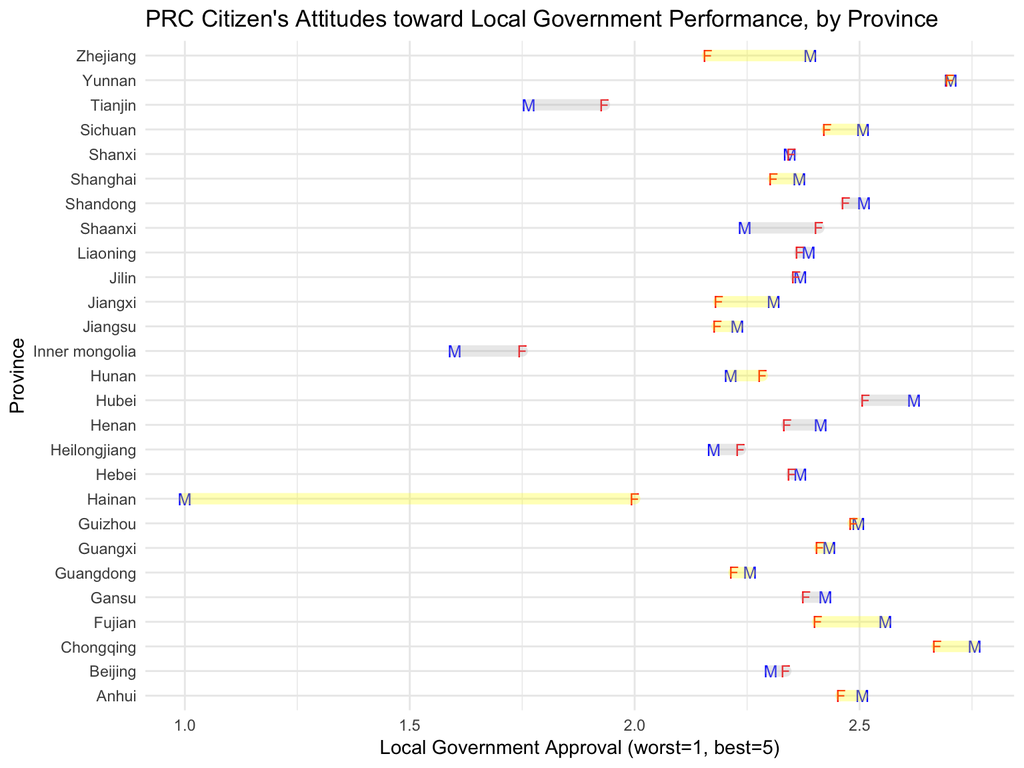

```r
## Read data from China Family Panel Studies into the dataset
dat$maleapproval <- 5-dat$male_approval ## Rescaled my government approaval scale from 1(best), 5(worst) to 1(worst), 5(best)
dat$femaleapproval <- 5-dat$female_approval
ggplot() +
  # define y = province level for all layers
  aes(y = dat$province) +
  # x = points for each actor
  geom_point(aes(x = dat$maleapproval), shape = "M", color= "blue", size=3) +
  geom_point(aes(x = dat$femaleapproval), shape = "F", color= "red", size=3) +
  ggtitle("PRC Citizen's Attitudes toward Local Government Performance, by Province") +
  geom_segment(aes(x = dat$maleapproval,
                   xend = dat$femaleapproval,
                   yend = dat$province),
               color = dat$regioncolor,
               size = 3,
               lineend = "round",
               alpha = .3) +
  labs(y = "Province",
       x = "Local Government Approval (worst=1, best=5)", size=3)
```